# predictionassignment

Sonia Marin

Thursday, November 19, 2015

## 1. INTRODUCTION

This is an Assignment for Practical Machine Learning Course. According to the information supply for the assignment, “Using devices such as Jawbone Up, Nike FuelBand, and Fitbit it is now possible to collect a large amount of data about personal activity relatively inexpensively. One thing that people regularly do is quantify how much of a particular activity they do, but they rarely quantify how well they do it. In this project, the goal will be to use data from accelerometers on the belt, forearm, arm, and dumbell of 6 participants. They were asked to perform barbell lifts correctly and incorrectly in 5 different ways. More information is available from the website here: http://groupware.les.inf.puc-rio.br/har (see the section on the Weight Lifting Exercise Dataset)”.

## 2. DESCRIPTION AND CLEANING OF DATA SET

The training data for this project are available in: https://d396qusza40orc.cloudfront.net/predmachlearn/pml-training.csv The test data are available in: https://d396qusza40orc.cloudfront.net/predmachlearn/pml-testing.csv The data for this project come from this source: http://groupware.les.inf.puc-rio.br/har.  
The goal of this project is to predict the manner in which they did the exercise. This is the “classe” variable in the training set.  
The análysis of data requires the use of several package and the data was read with the following code:

```r
library(ggplot2)
library(caret)
library(stats)
library(rpart)
library(YaleToolkit)
library(MASS)
datapmltraining<-read.table("./prediction assignment data/pml-training.csv",  sep=",", header=TRUE)
dim(datapmltraining)
```

```
## [1] 19622   160
```

```r
datapmltesting<-read.table("./prediction assignment data/pml-testing.csv", sep=",", header=TRUE)
dim(datapmltesting)
```

```
## [1]  20 160
```

The summary of training data set shows that there are many missing values, which need to be cleaned. In this case, with the function NearZeroVar, many of them were eliminated. Also the package YaleToolkit was used to clean the missing values. Additionally, the first 6 variables were eliminated to keep only numeric variables.

```r
nzv<-nearZeroVar(datapmltraining, saveMetrics=FALSE)
newdatatraining<-datapmltraining[,-nzv]
dim(newdatatraining)
```

```
## [1] 19622   100
```

```r
newdatatesting<-datapmltesting[,-nzv]
dim(newdatatesting)
```

```
## [1]  20 100
```

```r
index<-whatis(newdatatraining)
bad<-which(index$missing != 0)
newdatatraining<-newdatatraining[,-bad]
dim(newdatatraining)
```

```
## [1] 19622    59
```

```r
newdatatesting<-newdatatesting[,-bad]
dim(newdatatesting)
```

```
## [1] 20 59
```

```r
newdatatraincor<-newdatatraining[,-c(1,2,3,4,5,6),]
newdatatestcor<-newdatatesting[,-c(1,2,3,4,5,6),]
```

## 3.SELECTING THE MODEL

The training and testing sample are created from the cleaned data (newdatatraincor). Since, the memory available in my laptop is 4 GB, I used 20% of data in the training data.

```r
set.seed(2222)
inTrain<- createDataPartition(y=newdatatraincor$classe, p=0.2, list=FALSE)
training <- newdatatraincor[inTrain,]
testing <- newdatatraincor[-inTrain,]
dim(training)
```

```
## [1] 3927   53
```

```r
dim(testing)
```

```
## [1] 15695    53
```

Several algorithms were tryed: Linear Discriminant Analysis(lda), Random Forest(rf), Recursing Partioning(rpart). In each case the accuracy was checked.The best accuracy was taken from Random Forest. Cross validation is included with 5 folds. See results bellow.

```r
x<-training[,-53]
y<-training$classe
##lda
modfit1<-train(x,y, method="lda",
        trControl=trainControl(method="cv", number=5), allowParallel=TRUE)
print(modfit1)
```

```
## Linear Discriminant Analysis
##
## 3927 samples
##   52 predictor
##    5 classes: 'A', 'B', 'C', 'D', 'E'
##
## No pre-processing
## Resampling: Cross-Validated (5 fold)
## Summary of sample sizes: 3141, 3141, 3142, 3142, 3142
## Resampling results
##
##   Accuracy   Kappa      Accuracy SD  Kappa SD
##   0.6954399  0.6144523  0.008494824  0.01112211
##
##
```

```r
pmodfit1<-predict(modfit1, newdata=testing[,-53])
cmmod1<-confusionMatrix(testing$classe,pmodfit1)
acc1<-cmmod1$overall[1]
#rf
modfit2<-train(x,y, method="rf", prox=TRUE,
          trControl=trainControl(method="cv", number=5), allowParallel=TRUE)
print(modfit2)
```

```
## Random Forest
##
## 3927 samples
##   52 predictor
##    5 classes: 'A', 'B', 'C', 'D', 'E'
##
## No pre-processing
## Resampling: Cross-Validated (5 fold)
## Summary of sample sizes: 3142, 3141, 3140, 3142, 3143
## Resampling results across tuning parameters:
##
##   mtry  Accuracy   Kappa      Accuracy SD  Kappa SD
##    2    0.9607915  0.9503771  0.008314960  0.010512563
##   27    0.9643516  0.9548692  0.008193109  0.010364518
##   52    0.9554402  0.9435988  0.007451383  0.009410231
##
## Accuracy was used to select the optimal model using  the largest value.
## The final value used for the model was mtry = 27.
```

```r
pmodfit2<-predict(modfit2, newdata=testing[,-53])
cmmod2<-confusionMatrix(testing$classe,pmodfit2)
acc2<-cmmod2$overall[1]
#rpart
modfit3<-train(x,y, method="rpart")
print(modfit3)
```

```
## CART
##
## 3927 samples
##   52 predictor
##    5 classes: 'A', 'B', 'C', 'D', 'E'
##
## No pre-processing
## Resampling: Bootstrapped (25 reps)
## Summary of sample sizes: 3927, 3927, 3927, 3927, 3927, 3927, ...
## Resampling results across tuning parameters:
##
##   cp          Accuracy   Kappa       Accuracy SD  Kappa SD
##   0.03806475  0.5187788  0.37935856  0.02192441   0.03473425
##   0.06332266  0.3922738  0.17049877  0.05490407   0.09073501
##   0.11632871  0.3119625  0.04420165  0.03815791   0.06030818
##
## Accuracy was used to select the optimal model using  the largest value.
## The final value used for the model was cp = 0.03806475.
```

```r
pmodfit3<-predict(modfit3, newdata=testing[,-53])
cmmod3<-confusionMatrix(testing$classe,pmodfit3)
acc3<-cmmod3$overall[1]
acc<-c("lda"=acc1,"rf"=acc2,"rpart"=acc3)
acc
```

```
##   lda.Accuracy    rf.Accuracy rpart.Accuracy
##      0.7031539      0.9681427      0.4948073
```

## 4. PREDICTION

The rf model will be the choosen, and less analysis the results for prediction.

```r
cmmod2
```

```
## Confusion Matrix and Statistics
##
##           Reference
## Prediction    A    B    C    D    E
##          A 4441   15    4    2    2
##          B  116 2853   55   11    2
##          C    0   85 2617   33    2
##          D    6   18   64 2470   14
##          E    3   11   24   33 2814
##
## Overall Statistics
##
##                Accuracy : 0.9681
##                  95% CI : (0.9653, 0.9708)
##     No Information Rate : 0.2909
##     P-Value [Acc > NIR] : < 2.2e-16
##
##                   Kappa : 0.9597
##  Mcnemar's Test P-Value : < 2.2e-16
##
## Statistics by Class:
##
##                      Class: A Class: B Class: C Class: D Class: E
## Sensitivity            0.9726   0.9567   0.9468   0.9690   0.9929
## Specificity            0.9979   0.9855   0.9907   0.9922   0.9945
## Pos Pred Value         0.9948   0.9394   0.9562   0.9603   0.9754
## Neg Pred Value         0.9889   0.9898   0.9887   0.9940   0.9984
## Prevalence             0.2909   0.1900   0.1761   0.1624   0.1806
## Detection Rate         0.2830   0.1818   0.1667   0.1574   0.1793
## Detection Prevalence   0.2844   0.1935   0.1744   0.1639   0.1838
## Balanced Accuracy      0.9853   0.9711   0.9688   0.9806   0.9937
```

```r
errorate<-(1-acc2)
badpred<-(20*errorate)
```

Let´s try to find importance variables

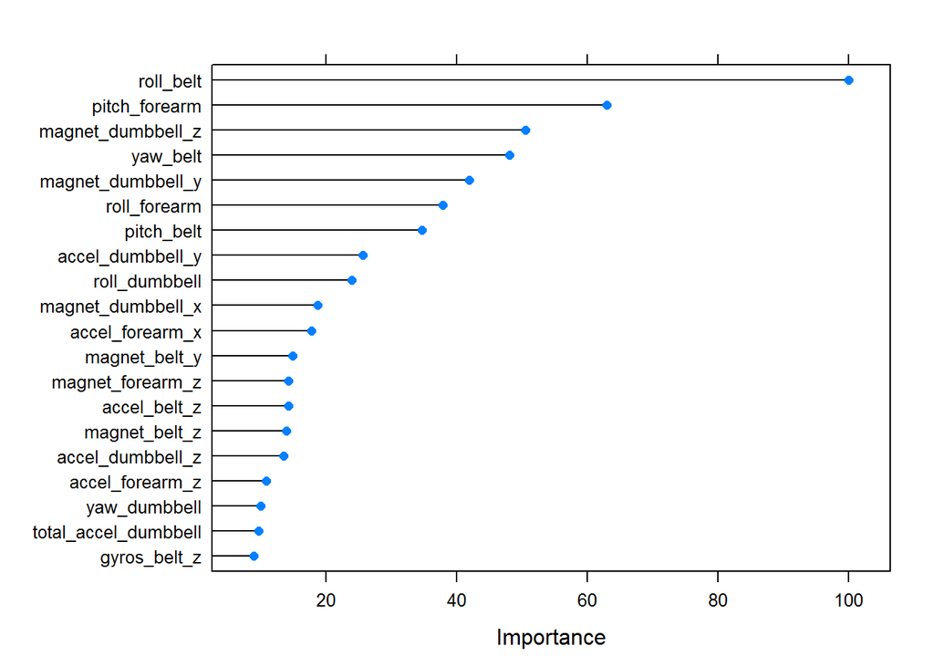

```r
compareObsPred <- data.frame(cbind(testing$classe), Predicted=pmodfit2)
varim<-varImp(modfit2, scale=TRUE)
plot(varim, top=20)
```

## 5. MISCLASSIFICATION ERROR

The misclassification error with rf model, 52 predictors and cross validation of 5 folds, is 1 less the accuracy, which is 0.0318573. With this error rate, I can expect that from the 20 cases, that I should have 0.6371456 bad predictions out of 20. Roughly this is 1 of 20.

## 6. PREDICTIONS OF THE 20 CASES

With the rf model, the prediction of the 20 cases is as follow:

```r
pmodfit20cases<-predict(modfit2, newdata=newdatatestcor[,-53])
pmodfit20cases
```

```
##  [1] B A B A A E D D A A B C B A E E A B B B
## Levels: A B C D E
```

```r
answers = as.character(pmodfit20cases)
answers
```

```
##  [1] "B" "A" "B" "A" "A" "E" "D" "D" "A" "A" "B" "C" "B" "A" "E" "E" "A"
## [18] "B" "B" "B"
```

```r
pml_write_files = function(x){
  n = length(x)
  for(i in 1:n){
    filename = paste0("problem_id_",i,".txt")
    write.table(x[i],file=filename,quote=FALSE,row.names=FALSE,col.names=FALSE)
  }
}
pml_write_files(answers)
```